# Debate Project

Scott Kelleher, Tulsi Gompo, Janalee Thompson

November 30, 2016

## **2016 Presidential Debate: Content Breakdown**

The 2016 presidential debates unfolded slowly as November approached. We watched candidates battle to the bittersweet end trying to convince the American people that they were the better-suited candidate to lead our country. According to CNN.com, over 84 million viewers tuned in to watch Hillary Clinton and Donald Trump debate. There were three debates in total spanning over a couple months. Some would consider these debates amusing (or scary) to say the least, such that terminology never before used in political discussions was broadcasted live for United States citizens and other countries to see in all its’ glory. “Piggy” and “deplorable” were just a couple words that were projected during the debates that caught the attention of some viewers. So what is it that we all do when we want to know more about something? We just “Google it” of course.

# **What were we thinking?**

As each debate unfolded, we wondered how many other people (like us) were using Google to search for termininology used in the debates- like the second amendment for example. Thus, we generated an analysis utilizing debate content and Google search terms. We started checking out Google Trends and tried trending some search terms ourselves. Google Trends is available to the general public with the purpose of displaying global search trends in Google. Google Trends adjusts Google searches by dividing each individual data point by total searches, geography and time range. In other words, this displays the term that was searched in relation to global search-volume. Trends in the data can be graphed by country or city.

Terms such as “second amendment” and “Isis” were some of the first terms we tried that we knew would probably prompt some pretty drastic search trends, which they did. Then, after using Google Trends to search what was intended to be a few words, we ended up searching a copious amount of terms (related and unrelated to the debates)! It was time to get down to business and locate the debate scripts and take some terms used by our candidates for a spin in Google Trends.

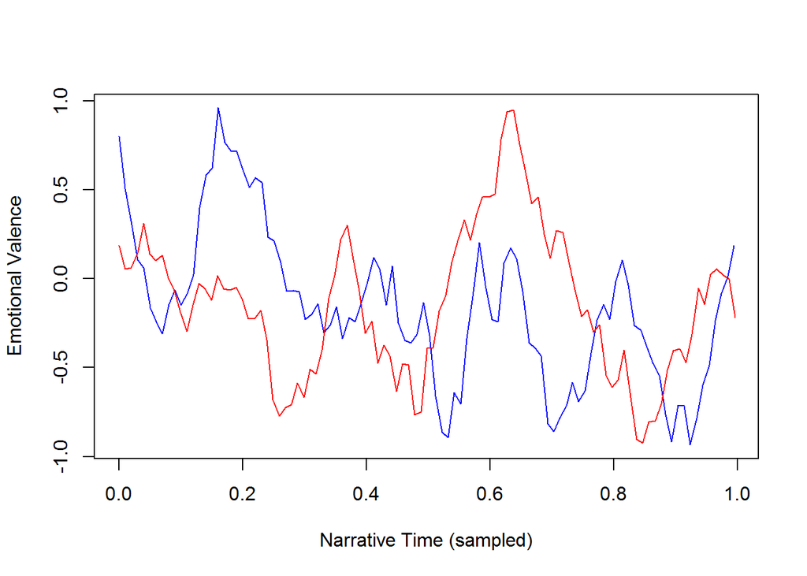

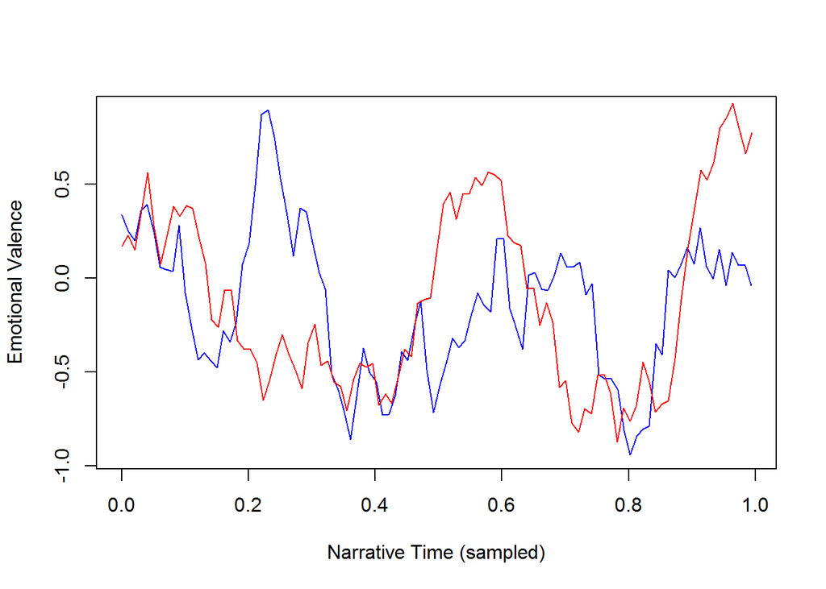

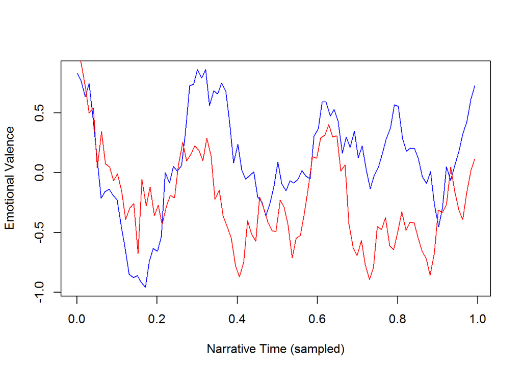

```r
for (i in (1:3)) {


  ##Getting the chunks of text and assigning the speaker, this just defines a function and we can place this actual code somewhere else later as long as we call the function
  text <- w[i]
  getLines <- function(person){

    id <- unlist(stringr::str_extract_all(text, "[A-Z]+:")) # get the speaker
    Lines <- unlist(strsplit(text, "[A-Z]+:"))[-1]  # split by speaker (and get rid of a pesky empty line)
    Lines[id %in% person] # retain speech by relevant speaker
  }

  ##Creating an object called debate_lines that has two parts, one for clinton and one for trump
  debate_lines <- lapply(c("CLINTON:", "TRUMP:"), getLines)


  ##Created two separate objects with "chunks" of text in each one, one for clinton and one for trump
  clinton_lines <- debate_lines[1]
  trump_lines <- debate_lines[2]





  #break into clinton lines
  text_clinton <- data_frame(text_c = clinton_lines[[1]])



  #break into trump lines
  text_trump <- data_frame(text_t = trump_lines[[1]])



  ##Breaking trump lines into individual words
  trump_words <- text_trump %>%
    unnest_tokens(word, text_t)
  #trump_words


  #filter out the stopwords, add which debate it was and the day and time
  trump_words_unique <- !(trump_words$word %in% stopwords())
  trump_words <- mutate(trump_words, elim = trump_words_unique, debate = i, date = date_time[i])
  trump_words<- filter(trump_words, trump_words$elim == TRUE)
  trump_words <- select(trump_words, -elim)
  if(i == 1){
    all_debate_words_trump<- trump_words
  } else{
    all_debate_words_trump <- bind_rows(all_debate_words_trump, trump_words)
  }


  ##Breaking clinton lines into individual words
  clinton_words <- text_clinton %>%
    unnest_tokens(word, text_c)
  #clinton_words



  #filter out the stopwords, add which debate it was and what day and time
  clinton_words_unique <- !(clinton_words$word %in% stopwords())
  clinton_words <- mutate(clinton_words, elim = clinton_words_unique, debate = i, date = date_time[i])
  clinton_words<- filter(clinton_words, clinton_words$elim == TRUE)
  clinton_words <- select(clinton_words, -elim)

  if(i == 1){
    all_debate_words_clinton<- clinton_words
  } else{
    all_debate_words_clinton <- bind_rows(all_debate_words_clinton, clinton_words)
  }


  sentiment_clinton <- get_sentiment(as.vector(clinton_words$word))
sentiment_trump <- get_sentiment(as.vector(trump_words$word))

pwdw <- round(length(sentiment_clinton)*.1)
clinton_rolled <- zoo::rollmean(sentiment_clinton, k=pwdw)
bwdw <- round(length(sentiment_trump)*.1)
trump_rolled <- zoo::rollmean(sentiment_trump, k=bwdw)
###############this is a good comparison between the candidates, not really smoothed much
clinton_list <- rescale_x_2(clinton_rolled)
 trump_list <- rescale_x_2(trump_rolled)
#
# plot(clinton_list$x,
#      clinton_list$z,
#      type="l",
#      col="blue",
#      xlab="Narrative Time",
#      ylab="Emotional Valence")
# lines(trump_list$x, trump_list$z, col="red")

######################################## the plots below are smoothed
poa_sample <- seq(1, length(clinton_list$x), by=round(length(clinton_list$x)/100))
bov_sample <- seq(1, length(trump_list$x), by=round(length(trump_list$x)/100))

plot(clinton_list$x[poa_sample],
     clinton_list$z[poa_sample],
     type="l",
     col="blue",
     xlab="Narrative Time (sampled)",
     ylab="Emotional Valence"
     )
lines(trump_list$x[bov_sample], trump_list$z[bov_sample], col="red")




}
```

```r
  ##Counting the number of times each word is said for clinton
  # clinton_word_frequency <- table(clinton_words)
  #
  #
  # ##Counting the number of times each word is said for trump
  # trump_word_frequency <- table(trump_words)
  #
  # ##Object that has word frequencies sorted from least to most for clinton
  # clinton_most_words <- sort(clinton_word_frequency)
  #
  #
  # ##Object that has word frequencies sorted from least to most for trump
  # trump_most_words <- sort(trump_word_frequency)
```